# Analysis of Global Compact COP reports

For this analysis we download from [here](https://www.unglobalcompact.org/participation/report/cop/create-and-submit/active) all COP reports submitted up to 2018. We only take into account the reports submitted in English.

Please specify below the focus year of this analysis. It will be consider as the end point of historical analyses, as well as the year for annual analyses.

```python
focus_year = "2018"
```

Please select the focus language using one of the following values:

- en (English, default option)
- de (German)
- es (Spanish)
- fr (French)
- pt (Portuguese)

```python
focus_language = 'en'
```

```python
language_ref = { 'en' : { 'name' : 'English', 'min_coocurrence' : 10},
                 'de' : { 'name' : 'German', 'min_coocurrence' : 2},
                 'es' : { 'name' : 'Spanish', 'min_coocurrence' : 2},
                 'fr' : { 'name' : 'French', 'min_coocurrence' : 2},
                 'pt' : { 'name' : 'Portuguese', 'min_coocurrence' : 2},
               }
```

## 1. Gathering information about COP reports available from the UN Global Compact website

The [UN Global Compact website](https://www.unglobalcompact.org/participation/report/cop/create-and-submit/active) contains entries for each COP report, describing the sector of the company submitting the report, country and year, as well as the language in which the repoort was written in and a link to a PDF file with the full report.

**The results in this section give a general view of the available COPs, it's not yet restricted by the focus_year and focus_language.**

```python
import requests
import re
from bs4 import BeautifulSoup

gc_url = "https://www.unglobalcompact.org/participation/report/cop/create-and-submit/active?page=1&per_page=10"
gc_base_url = "https://www.unglobalcompact.org"

gc_home = requests.get(gc_url)

soup = BeautifulSoup(gc_home.content, 'lxml')

header = soup.h2.string

total_num_cops = re.search(r'(?<=: )[0-9]+', header)[0]
print("Total number of COPs available: %s" % total_num_cops)
```

```
Total number of COPs available: 39012
```

```python
import pandas as pd

reports_index_csv_filename = "../data/cops/reports_index.csv"

df_pdfs = pd.read_csv(reports_index_csv_filename, sep='\t', encoding='utf-8', index_col=0, dtype={'year': object})
pdfs = df_pdfs.to_dict(orient='index')
```

## 2. Selecting COP reports that match required criteria (up to focus_year, written in focus_language)

```python
selected_sectors = {}
selected_countries = {}
selected_years = {}
selected_countries_years = {}
selected_sectors_years = {}

selected_pdfs = {}

for pdf in pdfs.keys():
    language = pdfs[pdf]["language"]
    year = pdfs[pdf]["year"]
    country = pdfs[pdf]["country"]
    sector = pdfs[pdf]["sector"]

    if language == language_ref[focus_language]['name'] and int(year) <= int(focus_year):
        selected_pdfs[pdf] = pdfs[pdf]

        selected_sectors[sector] = selected_sectors.get(sector,0) + 1
        selected_countries[country] = selected_countries.get(country,0) + 1
        selected_years[year] = selected_years.get(year,0) + 1
        if country in selected_countries_years.keys():
            selected_countries_years[country][year] = selected_countries_years[country].get(year,0) + 1
        else:
            selected_countries_years[country] = {year : 1}

        if sector in selected_sectors_years.keys():
            selected_sectors_years[sector][year] = selected_sectors_years[sector].get(year,0) + 1
        else:
            selected_sectors_years[sector] = {year : 1}
```

## 4. Extracting text from the PDF file of each report

A folder should be specified as the location where text files will be saved at ('txts_folder' variable below).

This process may fail to extract the text from some PDF files.

If this process has been run before and some text files are already available in the specified folder, they won't be processed again.

```python
filenameregex = re.compile(r'(?<=/)[^$/]+(?=$)')
```

```python
txts_folder = "../data/cops/txts/"
```

## 5. Analysing the text of reports: searching for health and climate mentions

### Keywords

```python
import json
import os
import re

keywords_file = os.path.join("..", "keywords", focus_language + ".json")

climate_dict = []
health_dict = []
compound_terms = []

def normalise_keywords(dictionary): #lowercases and handles compounds
    for i in range(0, len(dictionary)):
        keyword = dictionary[i].lower()
        compound = keyword.replace(' ','_')
        if compound != keyword:
            keyword = compound
            words = tuple(compound.split('_'))
            compound_terms.append(words)
        dictionary[i] = keyword
    return dictionary

def generate_hashtags(dictionary):
    hashtags_dict = []
    for keyword in dictionary:
        hashtags_dict.append("#" + keyword.replace('_',''))
    return hashtags_dict

with open(keywords_file) as f:
    data = json.load(f)

climate_dict = normalise_keywords(data['climate'])
health_dict = normalise_keywords(data['health'])

climate_hashtag_dict = generate_hashtags(climate_dict)
health_hashtag_dict = generate_hashtags(health_dict)
```

```python
health_dict
```

```
['malaria',
 'diarrhoea',
 'infection',
 'disease',
 'sars',
 'measles',
 'pneumonia',
 'epidemic',
 'pandemic',
 'public_health',
 'healthcare',
 'epidemiology',
 'health_care',
 'health',
 'mortality',
 'morbidity',
 'nutrition',
 'illness',
 'infectious',
 'ncd',
 'non-communicable_disease',
 'noncommunicable_disease',
 'communicable_disease',
 'air_pollution',
 'nutrition',
 'malnutrition',
 'mental_disorder',
 'stunting']
```

```python
climate_dict
```

```
['climate_change',
 'global_warming',
 'green_house',
 'temperature',
 'extreme_weather',
 'global_environmental_change',
 'climate_variability',
 'greenhouse',
 'low_carbon',
 'ghge',
 'renewable_energy',
 'carbon_emission',
 'co2_emission',
 'climate_pollutant']
```

```python
who_regions = {}

who_regions["Africa"] = ["Algeria", "Angola", "Benin", "Botswana", "British Indian Ocean Territory",
                         "Burkina Faso", "Burundi", "Cabo Verde", "Cameroon", "Central African Republic",
                         "Chad", "Comoros", "Congo, Democratic Republic of the", "Cote d'Ivoire",
                         "Democratic Republic of the Congo", "Congo, Republic of the",
                         "Equatorial Guinea", "Eritrea", "Ethiopia", "French Southern Territories", "Gabon",
                         "Gambia", "Ghana", "Guinea", "Guinea-Bissau", "Kenya", "Lesotho", "Liberia",
                         "Madagascar", "Malawi", "Mali", "Mauritania", "Mauritius", "Mayotte", "Mozambique",
                         "Namibia", "Niger", "Nigeria", "Rwanda", "Réunion", "Saint Helena",
                         "Sao Tome And Principe", "Senegal", "Seychelles", "Sierra Leone", "South Africa",
                         "South Sudan", "Swaziland", "Togo", "Uganda", "Tanzania, United Republic of",
                         "Western Sahara", "Zambia", "Zimbabwe"]

who_regions["Eastern Mediterranean"] = ["Afghanistan", "Bahrain", "Djibouti", "Egypt",
                                        "Iran, Islamic Republic of", "Iraq", "Jordan", "Kuwait", "Lebanon",
                                        "Libya", "Morocco", "Oman", "Pakistan", "Qatar", "Saudi Arabia",
                                        "Somalia", "Palestine, State of", "Sudan", "Syrian Arab Republic",
                                        "Tunisia", "United Arab Emirates", "Yemen"]

who_regions["Europe"] = ["Albania", "Andorra", "Armenia", "Austria", "Azerbaijan", "Belarus", "Belgium",
                         "Bosnia-Herzegovina", "Bulgaria", "Croatia", "Cyprus", "Czechia", "Denmark",
                         "Estonia", "Faroe Islands", "Finland", "France", "Georgia", "Germany", "Gibraltar",
                         "Greece", "Guernsey", "Holy See", "Hungary", "Iceland", "Ireland", "Isle of Man",
                         "Israel", "Italy", "Jersey", "Kazakhstan", "Kyrgyzstan", "Latvia", "Liechtenstein",
                         "Lithuania", "Luxembourg", "Malta", "Monaco", "Montenegro", "Netherlands", "North Macedonia", "Norway",
                         "Poland", "Portugal", "Moldova, Republic of", "Romania", "Russian Federation",
                         "San Marino", "Sark", "Serbia", "Slovakia", "Slovenia", "Spain",
                         "Svalbard and Jan Mayen Islands", "Sweden", "Switzerland", "Tajikistan",
                         "Macedonia, The former Yugoslav Republic of", "Turkey", "Turkmenistan", "Ukraine",
                         "United Kingdom", "Uzbekistan",
                         "Åland Islands"]

who_regions["Latin America and the Caribbean"] = ["Anguilla", "Antigua and Barbuda", "Argentina", "Aruba",
                                                  "Bahamas", "Barbados", "Belize", "Bolivia", "Bonaire",
                                                  "Bouvet Island", "Brazil", "British Virgin Islands",
                                                  "Cayman Islands", "Chile", "Colombia", "Costa Rica", "Cuba",
                                                  "Curaçao", "Dominica", "Dominican Republic", "Ecuador",
                                                  "El Salvador", "Falkland Islands (Malvinas)", "French Guiana",
                                                  "Grenada", "Guadeloupe", "Guatemala", "Guyana", "Haiti",
                                                  "Honduras", "Jamaica", "Martinique", "Mexico", "Montserrat",
                                                  "Nicaragua", "Panama", "Paraguay", "Peru", "Puerto Rico",
                                                  "Saint Barthթlemy", "Saint Kitts and Nevis", "Saint Lucia",
                                                  "Saint Martin", "Saint Vincent and the Grenadines",
                                                  "Sint Maarten", "South Georgia and the South Sandwich Islands",
                                                  "Suriname", "Trinidad And Tobago", "Turks and Caicos Islands",
                                                  "Virgin Islands", "Uruguay", "Venezuela"]

who_regions["North America"] = ["Bermuda", "Canada", "Greenland", "Saint Pierre and Miquelon",
                                "United States of America"]

who_regions["South-East Asia"] = ["Bangladesh", "Bhutan", "Democratic People's Republic of Korea", "India",
                                  "Indonesia", "Maldives", "Myanmar", "Nepal", "Sri Lanka", "Thailand",
                                  "Timor-Leste"]

who_regions["Western Pacific"] = ["American Samoa", "Australia", "Brunei", "Cambodia", "China",
                                  "Hong Kong", "Macao", "Taiwan", "Christmas Island", "Cocos (Keeling) Islands",
                                  "Cook Islands", "Fiji", "French Polynesia", "Guam",
                                  "Heard Island and McDonald Islands", "Japan", "Kiribati",
                                  "Laos", "Malaysia", "Marshall Islands", "Micronesia", "Mongolia", "Nauru",
                                  "New Caledonia", "New Zealand", "Niue", "Norfolk Island",
                                  "Northern Mariana Islands", "Palau", "Papua New Guinea", "Philippines",
                                  "Pitcairn", "Korea, Republic of", "Samoa", "Singapore", "Solomon Islands",
                                  "Tokelau", "Tonga", "Tuvalu", "Minor Outlying Islands", "Vanuatu",
                                  "Viet Nam", "Wallis and Futuna Islands"]
```

```python
def get_who_region(country):
    for region in who_regions:
        if country in who_regions[region]:
            return region
    if "..." in country:
        abrev_country_name = re.search(r'(?<=^)[^\.]+', country)[0]
        for region in who_regions:
            for c in who_regions[region]:
                if re.match(abrev_country_name, c):
                    return region
    print("Country not found among WHO regions: %s" % country)
    return False
```

```python
# run only if using WHO regions for analysis in text analysis.
selected_regions_years = {}
for region in who_regions.keys():
    selected_regions_years[region] = {}
for country in selected_countries_years.keys():
    region = get_who_region(country)
    if region:
        for year in selected_countries_years[country].keys():
            selected_regions_years[region][year] = selected_regions_years[region].get(year, 0) + selected_countries_years[country][year]
```

```python
new_regions = {}
new_regions['sids'] = ["American Samoa", "Anguilla", "Antigua and Barbuda", "Bahamas", "Bahrain", "Barbados", "Belize", "Bermuda", "Cape Verde", "Comoros", "Cook Islands", "Cuba", "Dominica", "Fiji", "Grenada", "Guam", "Guinea-Bissau", "Guyana", "Haiti", "Jamaica", "Kiribati", "Maldives", "Marshall Islands", "Mauritius", "Micronesia", "Montserrat", "Nauru", "New Caledonia", "Niue", "Palau", "Papua New Guinea", "Puerto Rico", "Saint Kitts and Nevis", "Saint Lucia", "Saint Vincent and the Grenadines", "Samoa", "Sao Tome and Principe", "Seychelles", "Singapore", "Solomon Islands", "Suriname", "Timor-Leste", "Tonga", "Trinidad and Tobago", "Tuvalu", "Vanuatu"]
new_regions['tier1'] = ["United States of America", "China"]
new_regions['tier2'] = ["Poland", "Australia", "South Africa", "Brazil", "India", "France", "Germany", "Indonesia", "United Kingdom"]

other = []
def get_new_region(country):
    for region in new_regions:
        if country in new_regions[region]:
            return region
    if "..." in country:
        abrev_country_name = re.search(r'(?<=^)[^\.]+', country)[0]
        for region in new_regions:
            for c in new_regions[region]:
                if re.match(abrev_country_name, c):
                    return region
    print("Country not found among new regions: %s" % country)
    other.append(country)
    return False
new_regions['other'] = other

selected_regions_years = {}
for region in new_regions.keys():
    selected_regions_years[region] = {}

for country in selected_countries_years.keys():
    region = get_new_region(country)
    if region:
        for year in selected_countries_years[country].keys():
            selected_regions_years[region][year] = selected_regions_years[region].get(year, 0) + selected_countries_years[country][year]
```

```
Country not found among new regions: Turkey
Country not found among new regions: Pakistan
Country not found among new regions: Belgium
Country not found among new regions: Israel
Country not found among new regions: Kuwait
Country not found among new regions: Luxembourg
Country not found among new regions: Spain
Country not found among new regions: Switzerland
Country not found among new regions: Thailand
Country not found among new regions: Denmark
Country not found among new regions: Mexico
Country not found among new regions: Netherlands
Country not found among new regions: Sweden
Country not found among new regions: Finland
Country not found among new regions: Philippines
Country not found among new regions: Norway
Country not found among new regions: Italy
Country not found among new regions: Lithuania
Country not found among new regions: Hungary
Country not found among new regions: Nigeria
Country not found among new regions: Korea, Repub...
Country not found among new regions: Uganda
Country not found among new regions: Mozambique
Country not found among new regions: Portugal
Country not found among new regions: Bangladesh
Country not found among new regions: Sierra Leone
Country not found among new regions: Austria
Country not found among new regions: Ukraine
Country not found among new regions: Greece
Country not found among new regions: Croatia
Country not found among new regions: Serbia
Country not found among new regions: Ghana
Country not found among new regions: Kenya
Country not found among new regions: Trinidad And...
Country not found among new regions: Sri Lanka
Country not found among new regions: Japan
Country not found among new regions: Canada
Country not found among new regions: Viet Nam
Country not found among new regions: Egypt
Country not found among new regions: Russian Fede...
```

[output cut: 59 more lines]

```
Country not found among new regions: Tunisia
Country not found among new regions: Sao Tome And...
Country not found among new regions: Cote d'Ivoire
Country not found among new regions: Zimbabwe
Country not found among new regions: Montenegro
Country not found among new regions: Afghanistan
Country not found among new regions: Somalia
Country not found among new regions: Cambodia
Country not found among new regions: Morocco
Country not found among new regions: Ethiopia
Country not found among new regions: Angola
Country not found among new regions: South Sudan
Country not found among new regions: Monaco
Country not found among new regions: Congo, Democ...
Country not found among new regions: Venezuela
```

```python
from nltk.tokenize import MWETokenizer

def get_context(index, wordlist):
    lowest_index = max(0, index-25)
    highest_index = min(index+1+25, len(wordlist))
    return wordlist[lowest_index:index] + wordlist[index+1:highest_index]

tokenizer = MWETokenizer(compound_terms)
regex = re.compile(r'^.{1,3}$') # words with 3 or less chars

types_count = {}
tokens_count = 0

per_sector = {}
average_per_sector = {}
proportion_per_sector = {}

per_sector_year_health = {}
average_per_sector_year_health = {}
proportion_per_sector_year_health = {}
per_sector_year_climate = {}
average_per_sector_year_climate = {}
proportion_per_sector_year_climate = {}
per_sector_year_intersection = {}
average_per_sector_year_intersection = {}
proportion_per_sector_year_intersection = {}

per_country = {}
per_country_focusyear = {}
average_per_country_focusyear = {}
proportion_per_country_focusyear = {}
per_year = {}
average_per_year = {}
proportion_per_year = {}
per_region = {}
per_region_year_intersection = {}
average_per_region_year_intersection = {}
proportion_per_region_year_intersection = {}
histogram_number_of_mentions = {}
histogram_tokens_count = []

global_count_health_keywords = {}
global_health_contexts = []
global_count_climate_keywords = {}
global_climate_contexts = []
global_intersection_contexts = []

cooccurrence_matrix = {}

for termset in ["health", "climate", "intersection"]:
    per_sector[termset] = {}
    average_per_sector[termset] = {}
    proportion_per_sector[termset] = {}
    per_country[termset] = {}
    per_country_focusyear[termset] = {}
    average_per_country_focusyear[termset] = {}
    proportion_per_country_focusyear[termset] = {}
    per_year[termset] = {}
    average_per_year[termset] = {}
    proportion_per_year[termset] = {}
    per_region[termset] = {}
    histogram_number_of_mentions[termset] = {}

for region in new_regions.keys():
    per_region_year_intersection[region] = {}
    average_per_region_year_intersection[region] = {}
    proportion_per_region_year_intersection[region] = {}

for sector in selected_sectors.keys():
    per_sector_year_health[sector] = {}
    average_per_sector_year_health[sector] = {}
    proportion_per_sector_year_health[sector] = {}
    per_sector_year_climate[sector] = {}
    average_per_sector_year_climate[sector] = {}
    proportion_per_sector_year_climate[sector] = {}
    per_sector_year_intersection[sector] = {}
    average_per_sector_year_intersection[sector] = {}
    proportion_per_sector_year_intersection[sector] = {}

for pdf in selected_pdfs.keys():
    filenametxt = txts_folder + filenameregex.search(pdf)[0] + ".txt"
    print("Loading %s" % (filenametxt))

    try:
        txtFileObj = open(filenametxt, 'r')
    except:
        print("Could not open {}".format(filenametxt))
        continue

    wordlist = re.split(r'[\W0-9]+', txtFileObj.read().lower())
    tokens_count += len(wordlist)
    histogram_tokens_count.append(len(wordlist))

    for word in wordlist:
        types_count[word] = types_count.get(word, 0) + 1

    compounds_wordlist = tokenizer.tokenize(wordlist)
    filtered_compounds_wordlist = [w for w in compounds_wordlist if (len(w) > 3)]

    health_contexts = []
    climate_contexts = []
    health_words = []

    for i in range(0,len(filtered_compounds_wordlist)):
        word = filtered_compounds_wordlist[i]
        if word in health_dict:
            context = get_context(i, filtered_compounds_wordlist)
            health_contexts.append(context)
            health_words.append(word)
            global_count_health_keywords[word] = global_count_health_keywords.get(word, 0) + 1
            global_health_contexts.extend(context)

        if word in climate_dict:
            context = get_context(i, filtered_compounds_wordlist)
            climate_contexts.append(context)
            global_count_climate_keywords[word] = global_count_climate_keywords.get(word, 0) + 1
            global_climate_contexts.extend(context)

    total_health_mentions = len(health_contexts)

    total_climate_mentions = len(climate_contexts)

    total_intersection_mentions = 0
    for i in range(0, len(health_contexts)):
        mention = health_contexts[i]
        hword = health_words[i]
        if hword not in cooccurrence_matrix.keys():
            cooccurrence_matrix[hword] = {}
        for cword in climate_dict:
            if cword in mention:
                total_intersection_mentions += 1
                global_intersection_contexts.extend(mention)
                cooccurrence_matrix[hword][cword] = cooccurrence_matrix[hword].get(cword, 0) + 1

    language = selected_pdfs[pdf]["language"]
    year = selected_pdfs[pdf]["year"]
    country = selected_pdfs[pdf]["country"]
    sector = selected_pdfs[pdf]["sector"]
    region = get_new_region(country)

    histogram_number_of_mentions["health"][total_health_mentions] = histogram_number_of_mentions["health"].get(total_health_mentions, 0) + 1
    histogram_number_of_mentions["climate"][total_climate_mentions] = histogram_number_of_mentions["climate"].get(total_climate_mentions, 0) + 1
    histogram_number_of_mentions["intersection"][total_intersection_mentions] = histogram_number_of_mentions["intersection"].get(total_intersection_mentions, 0) + 1

    per_sector["health"][sector] = per_sector["health"].get(sector,0) + total_health_mentions
    per_sector["climate"][sector] = per_sector["climate"].get(sector,0) + total_climate_mentions
    per_sector["intersection"][sector] = per_sector["intersection"].get(sector,0) + total_intersection_mentions

    per_sector_year_health[sector][year] = per_sector_year_health[sector].get(year,0) + total_health_mentions
    per_sector_year_climate[sector][year] = per_sector_year_climate[sector].get(year,0) + total_climate_mentions
    per_sector_year_intersection[sector][year] = per_sector_year_intersection[sector].get(year,0) + total_intersection_mentions

    per_country["health"][country] = per_country["health"].get(country,0) + total_health_mentions
    per_country["climate"][country] = per_country["climate"].get(country,0) + total_climate_mentions
    per_country["intersection"][country] = per_country["intersection"].get(country,0) + total_intersection_mentions
```

```python
    if year == focus_year:
        per_country_focusyear["health"][country] = per_country_focusyear["health"].get(country,0) + total_health_mentions
        per_country_focusyear["climate"][country] = per_country_focusyear["climate"].get(country,0) + total_climate_mentions
        per_country_focusyear["intersection"][country] = per_country_focusyear["intersection"].get(country,0) + total_intersection_mentions

    if region != False:
        per_region["health"][region] = per_region["health"].get(region,0) + total_health_mentions
        per_region["climate"][region] = per_region["climate"].get(region,0) + total_climate_mentions
        per_region["intersection"][region] = per_region["intersection"].get(region,0) + total_intersection_mentions
        per_region_year_intersection[region][year] = per_region_year_intersection[region].get(year,0) + total_intersection_mentions

    per_year["health"][year] = per_year["health"].get(year,0) + total_health_mentions
    per_year["climate"][year] = per_year["climate"].get(year,0) + total_climate_mentions
    per_year["intersection"][year] = per_year["intersection"].get(year,0) + total_intersection_mentions

    if total_health_mentions > 0:
        proportion_per_year["health"][year] = proportion_per_year["health"].get(year,0) + 1
        proportion_per_sector["health"][sector] = proportion_per_sector["health"].get(sector,0) + 1
        if year == focus_year:
            proportion_per_country_focusyear["health"][country] = proportion_per_country_focusyear["health"].get(country,0) + 1
        proportion_per_sector_year_health[sector][year] = proportion_per_sector_year_health[sector].get(year,0) + 1

    if total_climate_mentions > 0:
        proportion_per_year["climate"][year] = proportion_per_year["climate"].get(year,0) + 1
        proportion_per_sector["climate"][sector] = proportion_per_sector["climate"].get(sector,0) + 1
        if year == focus_year:
            proportion_per_country_focusyear["climate"][country] = proportion_per_country_focusyear["climate"].get(country,0) + 1
        proportion_per_sector_year_climate[sector][year] = proportion_per_sector_year_climate[sector].get(year,0) + 1

    if total_intersection_mentions > 0:
        proportion_per_year["intersection"][year] = proportion_per_year["intersection"].get(year,0) + 1
        proportion_per_sector["intersection"][sector] = proportion_per_sector["intersection"].get(sector,0) + 1
        if year == focus_year:
            proportion_per_country_focusyear["intersection"][country] = proportion_per_country_focusyear["intersection"].get(country,0) + 1
        proportion_per_region_year_intersection[region][year] = proportion_per_region_year_intersection[region].get(year,0) + 1
        proportion_per_sector_year_intersection[sector][year] = proportion_per_sector_year_intersection[sector].get(year,0) + 1

for year in selected_years.keys():
    average_per_year["health"][year] = per_year["health"][year]/selected_years[year]
    average_per_year["climate"][year] = per_year["climate"][year]/selected_years[year]
    average_per_year["intersection"][year] = per_year["intersection"][year]/selected_years[year]

    proportion_per_year["health"][year] = proportion_per_year["health"].get(year,0)/selected_years[year] * 100
    proportion_per_year["climate"][year] = proportion_per_year["climate"].get(year,0)/selected_years[year] * 100
    proportion_per_year["intersection"][year] = proportion_per_year["intersection"].get(year,0)/selected_years[year] * 100

for country in selected_countries_years.keys():
    if focus_year in selected_countries_years[country].keys():
        average_per_country_focusyear["health"][country] = per_country_focusyear["health"].get(country, 0)/selected_countries_years[country][focus_year]
        average_per_country_focusyear["climate"][country] = per_country_focusyear["climate"].get(country, 0)/selected_countries_years[country][focus_year]
        average_per_country_focusyear["intersection"][country] = per_country_focusyear["intersection"].get(country, 0)/selected_countries_years[country][focus_year]

        proportion_per_country_focusyear["health"][country] = proportion_per_country_focusyear["health"].get(country,0)/selected_countries_years[country][focus_year] * 100
        proportion_per_country_focusyear["climate"][country] = proportion_per_country_focusyear["climate"].get(country,0)/selected_countries_years[country][focus_year] * 100
        proportion_per_country_focusyear["intersection"][country] = proportion_per_country_focusyear["intersection"].get(country,0)/selected_countries_years[country][focus_year] * 100

for region in selected_regions_years.keys():
    for year in selected_regions_years[region].keys():
        average_per_region_year_intersection[region][year] = per_region_year_intersection[region].get(year,0)/selected_regions_years[region][year]
        proportion_per_region_year_intersection[region][year] = proportion_per_region_year_intersection[region].get(year,0)/selected_regions_years[region][year] * 100

for sector in selected_sectors.keys():
    average_per_sector["health"][sector] = per_sector["health"][sector]/selected_sectors[sector]
    average_per_sector["climate"][sector] = per_sector["climate"][sector]/selected_sectors[sector]
    average_per_sector["intersection"][sector] = per_sector["intersection"][sector]/selected_sectors[sector]

    proportion_per_sector["health"][sector] = proportion_per_sector["health"].get(sector,0)/selected_sectors[sector] * 100
    proportion_per_sector["climate"][sector] = proportion_per_sector["climate"].get(sector,0)/selected_sectors[sector] * 100
    proportion_per_sector["intersection"][sector] = proportion_per_sector["intersection"].get(sector,0)/selected_sectors[sector] * 100

for sector in selected_sectors_years.keys():
    for year in selected_sectors_years[sector].keys():
        average_per_sector_year_health[sector][year] = per_sector_year_health[sector].get(year,0)/selected_sectors_years[sector][year]
        average_per_sector_year_climate[sector][year] = per_sector_year_climate[sector].get(year,0)/selected_sectors_years[sector][year]
        average_per_sector_year_intersection[sector][year] = per_sector_year_intersection[sector].get(year,0)/selected_sectors_years[sector][year]
```

```python
        proportion_per_sector_year_health[sector][year] = proportion_per_sector_year_health[sector].get(year,0)/selected_sectors_years[sector][year] * 100
        proportion_per_sector_year_climate[sector][year] = proportion_per_sector_year_climate[sector].get(year,0)/selected_sectors_years[sector][year] * 100
        proportion_per_sector_year_intersection[sector][year] = proportion_per_sector_year_intersection[sector].get(year,0)/selected_sectors_years[sector][year] * 100
```

[output not shown]

[output cut: 17845 more lines]

[output not shown]

## 6. Visualising the result of the text analysis

### References per year: total, average, proportion, per region (new)

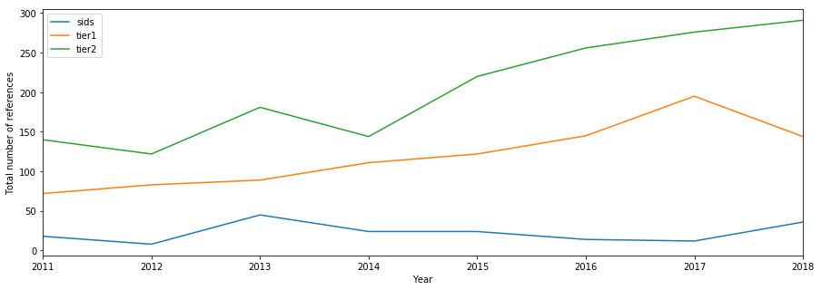

```python
df_per_region_year_intersection = pd.DataFrame(data=per_region_year_intersection)
ax = df_per_region_year_intersection[['sids','tier1','tier2']].filter(items=['2011','2012','2013','2014','2015','2016','2017','2018'],axis=0).plot.line(figsize=(15,5))
ax.set_xticklabels(['2011','2012','2013','2014','2015','2016','2017','2018'])
ax.set_xlabel("Year")
ax.set_ylabel("Total number of references")
ax
```

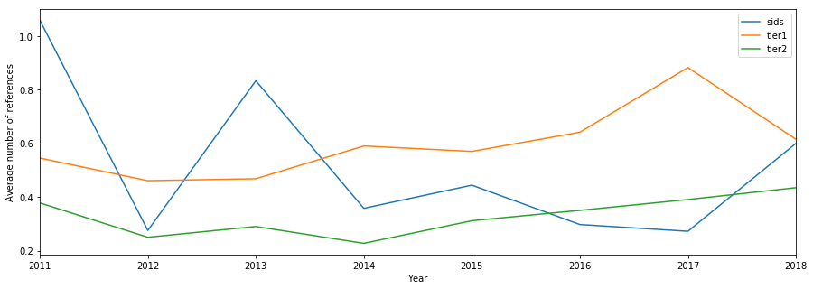

```python
df_average_per_region_year_intersection = pd.DataFrame(data=average_per_region_year_intersection)
ax = df_average_per_region_year_intersection[['sids','tier1','tier2']].filter(items=['2011','2012','2013','2014','2015','2016','2017','2018'],axis=0).plot.line(figsize=(15,5))
ax.set_xticklabels(['2011','2012','2013','2014','2015','2016','2017','2018'])
ax.set_xlabel("Year")
ax.set_ylabel("Average number of references")
ax
```

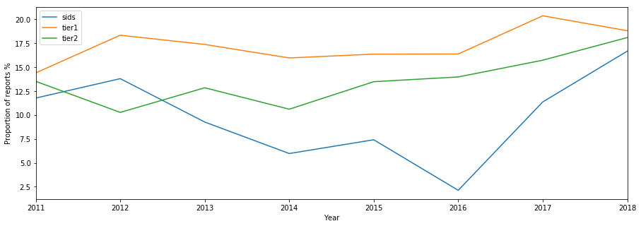

```python
df_proportion_per_region_year_intersection = pd.DataFrame(proportion_per_region_year_intersection)
ax = df_proportion_per_region_year_intersection[['sids','tier1','tier2']].filter(items=['2011','2012','2013','2014','2015','2016','2017','2018'],axis=0).plot.line(figsize=(15,5))
ax.set_xticklabels(['2011','2012','2013','2014','2015','2016','2017','2018'])
ax.set_xlabel("Year")
ax.set_ylabel("Proportion of reports %")
ax
```

### References per sector: total, average, proportion

For one specific sector “Health Care Equipment and Services” produce graphs of trend lines for health, climate change, and intersection over the complete time period:

- 2.1 Total count of mentions
- 2.2 Proportion of all reports for this sector that mention at least once
- 2.3 Proportion per country group (sids, tier1, tier 2)
- 2.4 Proportion per WHO region

#### 2.1 Total Count of Mentions

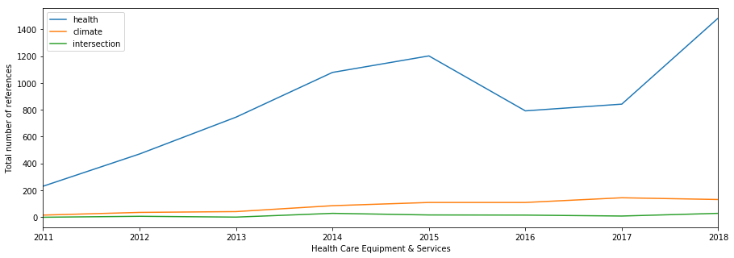

```python
df_per_sector_year_climate = pd.DataFrame(per_sector_year_climate)
df_per_sector_year_health = pd.DataFrame(per_sector_year_health)
df_per_sector_year_intersection = pd.DataFrame(per_sector_year_intersection)
df_hces_per_year = pd.concat([df_per_sector_year_health['Health Care Equipment & Ser...'], df_per_sector_year_climate['Health Care Equipment & Ser...'], df_per_sector_year_intersection['Health Care Equipment & Ser...']], axis=1, keys=['health', 'climate', 'intersection'])

ax = df_hces_per_year.filter(items=['2011','2012','2013','2014','2015','2016','2017','2018'],axis=0).plot.line(figsize=(15,5))
ax.set_xticklabels(['2011','2012','2013','2014','2015','2016','2017','2018'])
ax.set_xlabel("Health Care Equipment & Services")
ax.set_ylabel("Total number of references")
ax
```

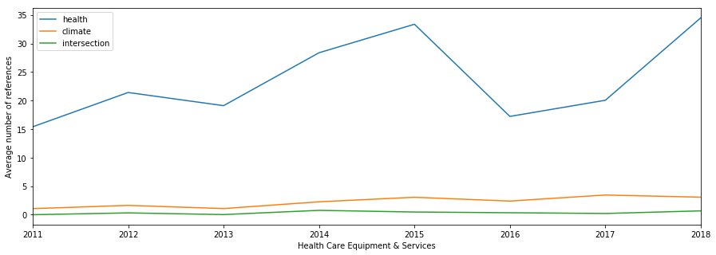

```python
df_average_per_sector_year_health = pd.DataFrame(average_per_sector_year_health)
df_average_per_sector_year_climate = pd.DataFrame(average_per_sector_year_climate)
df_average_per_sector_year_intersection = pd.DataFrame(average_per_sector_year_intersection)
df_hces_average_per_year = pd.concat([df_average_per_sector_year_health['Health Care Equipment & Ser...'], df_average_per_sector_year_climate['Health Care Equipment & Ser...'], df_average_per_sector_year_intersection['Health Care Equipment & Ser...']], axis=1, keys=['health', 'climate', 'intersection'])

ax = df_hces_average_per_year.filter(items=['2011','2012','2013','2014','2015','2016','2017','2018'],axis=0).plot.line(figsize=(15,5))
ax.set_xticklabels(['2011','2012','2013','2014','2015','2016','2017','2018'])
ax.set_xlabel("Health Care Equipment & Services")
ax.set_ylabel("Average number of references")
ax
```

#### 2.2 Proportion of all reports for this sector that mention at least once

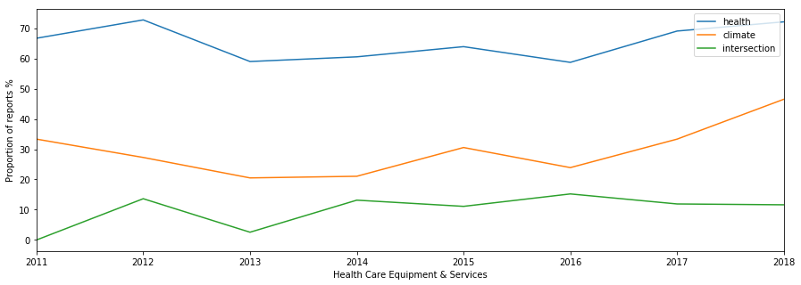

```python
df_proportion_per_sector_year_health = pd.DataFrame(proportion_per_sector_year_health)
df_proportion_per_sector_year_climate = pd.DataFrame(proportion_per_sector_year_climate)
df_proportion_per_sector_year_intersection = pd.DataFrame(proportion_per_sector_year_intersection)
df_hces_proportion_per_year = pd.concat([df_proportion_per_sector_year_health['Health Care Equipment & Ser...'], df_proportion_per_sector_year_climate['Health Care Equipment & Ser...'], df_proportion_per_sector_year_intersection['Health Care Equipment & Ser...']], axis=1, keys=['health', 'climate', 'intersection'])

ax = df_hces_proportion_per_year.filter(items=['2011','2012','2013','2014','2015','2016','2017','2018'],axis=0).plot.line(figsize=(15,5))
ax.set_xticklabels(['2011','2012','2013','2014','2015','2016','2017','2018'])
ax.set_xlabel("Health Care Equipment & Services")
ax.set_ylabel("Proportion of reports %")
ax
```

```python
df_hces_proportion_per_year
```

|  | health | climate | intersection |
| --- | --- | --- | --- |
| 2004 | NaN | NaN | NaN |
| 2005 | NaN | NaN | NaN |
| 2006 | NaN | NaN | NaN |
| 2007 | NaN | NaN | NaN |
| 2008 | NaN | NaN | NaN |
| 2009 | NaN | NaN | NaN |
| 2010 | NaN | NaN | NaN |
| 2011 | 66.666667 | 33.333333 | 0.000000 |
| 2012 | 72.727273 | 27.272727 | 13.636364 |
| 2013 | 58.974359 | 20.512821 | 2.564103 |
| 2014 | 60.526316 | 21.052632 | 13.157895 |
| 2015 | 63.888889 | 30.555556 | 11.111111 |
| 2016 | 58.695652 | 23.913043 | 15.217391 |
| 2017 | 69.047619 | 33.333333 | 11.904762 |
| 2018 | 72.093023 | 46.511628 | 11.627907 |

#### 2.3 Proportion per country group (sids, tier1, tier 2)

```python
df_selected_pdfs = pd.DataFrame(selected_pdfs).transpose().filter(items=['country', 'sector', 'year'])
```

```python
df_selected_pdfs_sector = df_selected_pdfs[df_selected_pdfs.sector == "Health Care Equipment & Ser..."]

sps_regions = []
for i in df_selected_pdfs_sector['country']:
    sps_region = get_new_region(i)
    sps_regions.append(sps_region)

df_selected_pdfs_sector['region'] = pd.DataFrame(sps_regions).values
```

```python
df_selected_pdfs_sector_region_year = df_selected_pdfs_sector[['year', 'region']]
```

```python
other_year_sum = []
for year in selected_sectors_years['Health Care Equipment & Ser...'].keys():
    year_sum=(sum(df_selected_pdfs_sector_region_year[df_selected_pdfs_sector_region_year.region=="other"].year==year)/sum(df_selected_pdfs_sector.year==year))*100
    other_year_sum.append(year_sum)
tier1_year_sum = []
for year in selected_sectors_years['Health Care Equipment & Ser...'].keys():
    year_sum=(sum(df_selected_pdfs_sector_region_year[df_selected_pdfs_sector_region_year.region=="tier1"].year==year)/sum(df_selected_pdfs_sector.year==year))*100
    tier1_year_sum.append(year_sum)
tier2_year_sum = []
for year in selected_sectors_years['Health Care Equipment & Ser...'].keys():
    year_sum=(sum(df_selected_pdfs_sector_region_year[df_selected_pdfs_sector_region_year.region=="tier2"].year==year)/sum(df_selected_pdfs_sector.year==year))*100
    tier2_year_sum.append(year_sum)
sids_year_sum = []
for year in selected_sectors_years['Health Care Equipment & Ser...'].keys():
    year_sum=(sum(df_selected_pdfs_sector_region_year[df_selected_pdfs_sector_region_year.region=="sids"].year==year)/sum(df_selected_pdfs_sector.year==year))*100
    sids_year_sum.append(year_sum)
```

```python
df_selected_pdfs_sector_region_year_proportion = pd.DataFrame([other_year_sum, tier1_year_sum, tier2_year_sum, sids_year_sum], columns=['2011','2012','2013','2014','2015','2016','2017','2018'])

df_selected_pdfs_sector_region_year_proportion = df_selected_pdfs_sector_region_year_proportion.rename(index = {0: "other",
                                                    1: "tier1",
                                                    2: "tier2",
                                                    3: "sids"}).transpose()
```

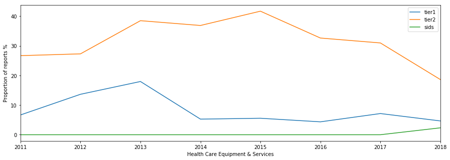

```python
ax = df_selected_pdfs_sector_region_year_proportion[['tier1', 'tier2', 'sids']].plot.line(figsize=(15,5))
ax.set_xlabel("Health Care Equipment & Services")
ax.set_ylabel("Proportion of reports %")
ax
```

#### 2.4 Proportion per WHO region

```python
df_selected_pdfs_sector = df_selected_pdfs[df_selected_pdfs.sector == "Health Care Equipment & Ser..."]

who_regions_list = []
for country in df_selected_pdfs_sector['country']:
    who_region_i = get_who_region(country)
    who_regions_list.append(who_region_i)

df_selected_pdfs_sector['who_region'] = pd.DataFrame(who_regions_list).values
```

```python
africa_year_sum = []
for year in selected_sectors_years['Health Care Equipment & Ser...'].keys():
    year_sum=(sum(df_selected_pdfs_sector[df_selected_pdfs_sector.who_region=="Africa"].year==year)/sum(df_selected_pdfs_sector.year==year))*100
    africa_year_sum.append(year_sum)

eam_year_sum = []
for year in selected_sectors_years['Health Care Equipment & Ser...'].keys():
    year_sum=(sum(df_selected_pdfs_sector[df_selected_pdfs_sector.who_region=="Eastern Mediterranean"].year==year)/sum(df_selected_pdfs_sector.year==year))*100
    eam_year_sum.append(year_sum)

eur_year_sum = []
for year in selected_sectors_years['Health Care Equipment & Ser...'].keys():
    year_sum=(sum(df_selected_pdfs_sector[df_selected_pdfs_sector.who_region=="Europe"].year==year)/sum(df_selected_pdfs_sector.year==year))*100
    eur_year_sum.append(year_sum)

lac_year_sum = []
for year in selected_sectors_years['Health Care Equipment & Ser...'].keys():
    year_sum=(sum(df_selected_pdfs_sector[df_selected_pdfs_sector.who_region=="Latin America and the Caribbean"].year==year)/sum(df_selected_pdfs_sector.year==year))*100
    lac_year_sum.append(year_sum)

na_year_sum = []
for year in selected_sectors_years['Health Care Equipment & Ser...'].keys():
    year_sum=(sum(df_selected_pdfs_sector[df_selected_pdfs_sector.who_region=="North America"].year==year)/sum(df_selected_pdfs_sector.year==year))*100
    na_year_sum.append(year_sum)

sea_year_sum = []
for year in selected_sectors_years['Health Care Equipment & Ser...'].keys():
    year_sum=(sum(df_selected_pdfs_sector[df_selected_pdfs_sector.who_region=="South-East Asia"].year==year)/sum(df_selected_pdfs_sector.year==year))*100
    sea_year_sum.append(year_sum)

wp_year_sum = []
for year in selected_sectors_years['Health Care Equipment & Ser...'].keys():
    year_sum=(sum(df_selected_pdfs_sector[df_selected_pdfs_sector.who_region=="Western Pacific"].year==year)/sum(df_selected_pdfs_sector.year==year))*100
    wp_year_sum.append(year_sum)
```

```python
df_selected_pdfs_sector_who_region_year_proportion = pd.DataFrame([africa_year_sum, eam_year_sum, eur_year_sum, lac_year_sum, na_year_sum, sea_year_sum, wp_year_sum], columns=['2011','2012','2013','2014','2015','2016','2017','2018'])

df_selected_pdfs_sector_who_region_year_proportion = df_selected_pdfs_sector_who_region_year_proportion.rename(index = {0: "Africa",
                                                                                                                  1: "Eastern Mediterranean",
                                                                                                                  2: "Europe",
                                                                                                                  3: "Latin America and the Caribbean",
                                                                                                                  4:"North America",
                                                                                                                  5:"South-East Asia",
                                                                                                                  6:"Western Pacific"}).transpose()
```

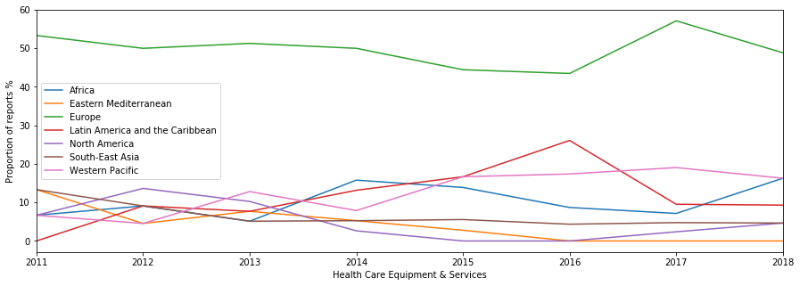

```python
ax = df_selected_pdfs_sector_who_region_year_proportion.plot.line(figsize=(15,5))
ax.set_xlabel("Health Care Equipment & Services")
ax.set_ylabel("Proportion of reports %")
ax
```

#### 3 English-Speaking Countries

- 3.1 USA
- 3.2 UK
- 3.3 Australia
- 3.4 Canada
- 3.5 New Zealand
- 3.6 South Africa

```python
df_selected_pdfs_sector = df_selected_pdfs[df_selected_pdfs.sector == "Health Care Equipment & Ser..."]
```

```python
english_speaking_countries = ['United State...', 'United Kingdom', 'Australia', 'Canada', 'New Zealand', 'South Africa']

df_selected_pdfs_sector_english = df_selected_pdfs_sector.loc[df_selected_pdfs_sector['country'].isin(english_speaking_countries)]
```

```python
us_year_sum = []
for year in selected_sectors_years['Health Care Equipment & Ser...'].keys():
    year_sum=(sum(df_selected_pdfs_sector_english[df_selected_pdfs_sector_english.country=="United State..."].year==year)/sum(df_selected_pdfs_sector.year==year))*100
    us_year_sum.append(year_sum)

uk_year_sum = []
for year in selected_sectors_years['Health Care Equipment & Ser...'].keys():
    year_sum=(sum(df_selected_pdfs_sector_english[df_selected_pdfs_sector_english.country=="United Kingdom"].year==year)/sum(df_selected_pdfs_sector.year==year))*100
    uk_year_sum.append(year_sum)

aus_year_sum = []
for year in selected_sectors_years['Health Care Equipment & Ser...'].keys():
    year_sum=(sum(df_selected_pdfs_sector_english[df_selected_pdfs_sector_english.country=="Australia"].year==year)/sum(df_selected_pdfs_sector.year==year))*100
    aus_year_sum.append(year_sum)

can_year_sum = []
for year in selected_sectors_years['Health Care Equipment & Ser...'].keys():
    year_sum=(sum(df_selected_pdfs_sector_english[df_selected_pdfs_sector_english.country=="Canada"].year==year)/sum(df_selected_pdfs_sector.year==year))*100
    can_year_sum.append(year_sum)

nz_year_sum = []
for year in selected_sectors_years['Health Care Equipment & Ser...'].keys():
    year_sum=(sum(df_selected_pdfs_sector_english[df_selected_pdfs_sector_english.country=="New Zealand"].year==year)/sum(df_selected_pdfs_sector.year==year))*100
    nz_year_sum.append(year_sum)

sa_year_sum = []
for year in selected_sectors_years['Health Care Equipment & Ser...'].keys():
    year_sum=(sum(df_selected_pdfs_sector_english[df_selected_pdfs_sector_english.country=="South Africa"].year==year)/sum(df_selected_pdfs_sector.year==year))*100
    sa_year_sum.append(year_sum)
```

```python
df_selected_pdfs_sector_english_year_proportion = pd.DataFrame([us_year_sum, uk_year_sum, aus_year_sum, can_year_sum, nz_year_sum, sa_year_sum], columns=['2011','2012','2013','2014','2015','2016','2017','2018'])

df_selected_pdfs_sector_english_year_proportion = df_selected_pdfs_sector_english_year_proportion.rename(index = {0: "United States",
                                                                                                                  1: "United Kingdom",
                                                                                                                  2: "Austalia",
                                                                                                                  3: "Canada",
                                                                                                                  4:"New Zealand",
                                                                                                                  5:"South Africa"}).transpose()
```

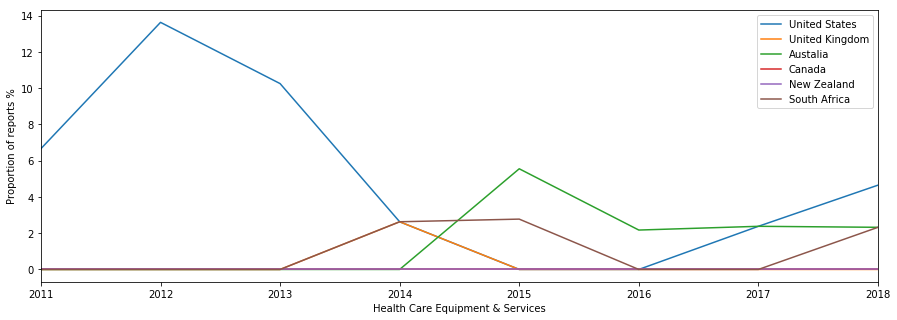

```python
ax = df_selected_pdfs_sector_english_year_proportion.plot.line(figsize=(15,5))
ax.set_xlabel("Health Care Equipment & Services")
ax.set_ylabel("Proportion of reports %")
ax
```

### Keywords

Produce the tables of frequency of keywords (health and climate) for the “Health Care Equipment and Services” sector.

```python
df_selected_pdfs_sector
```

|  | country | sector | year |
| --- | --- | --- | --- |
| /system/attachments/10046/original/Tana_Netting_CSR_Report_2010.pdf?1303879734 | Thailand | Health Care Equipment & Ser... | 2011 |
| /system/attachments/10283/original/WDH_UNGC_COP_2011.pdf?1305122127 | Denmark | Health Care Equipment & Ser... | 2011 |
| /system/attachments/10420/original/COP_CDI_Dental_-_2011-05-15..pdf?1306151456 | Sweden | Health Care Equipment & Ser... | 2011 |
| /system/attachments/10481/original/Radiometer_Medical_-_CSR_Status_GC_2010.pdf?1306482668 | Denmark | Health Care Equipment & Ser... | 2011 |
| /system/attachments/10691/original/ESSILOR_RegistrationDocument_2010.pdf?1307612983 | France | Health Care Equipment & Ser... | 2011 |
| /system/attachments/10692/original/COP_2011_Renewed_Committment_of_the_Chairman_of_the_Board_of_Directors.pdf?1307612983 | France | Health Care Equipment & Ser... | 2011 |
| /system/attachments/10794/original/ELARD_COP-10_principles_June_2011.pdf?1308225730 | Syrian Arab ... | Health Care Equipment & Ser... | 2011 |
| /system/attachments/11127/original/Sawaf_20Medical_20Institute_20for_20Imaging_20COP_20FINAL._1_.pdf?1310025099 | Syrian Arab ... | Health Care Equipment & Ser... | 2011 |
| /system/attachments/11580/original/Communication_on_Progress_-_WaterHealth_India_-_2011_Version_2_.pdf?1312956935 | India | Health Care Equipment & Ser... | 2011 |
| /system/attachments/12509/original/Merkez_la_COP.pdf?1319629628 | Turkey | Health Care Equipment & Ser... | 2011 |
| /system/attachments/12873/original/UN_Global_Report_2011_Final.pdf?1321298747 | United State... | Health Care Equipment & Ser... | 2011 |
| /system/attachments/13461/original/sysmex_sustainability_report_2011.pdf?1324270204 | Japan | Health Care Equipment & Ser... | 2011 |
| /system/attachments/13622/original/KARL_STORZ_Global_Compact_2011-E.pdf?1325233558 | Germany | Health Care Equipment & Ser... | 2011 |
| /system/attachments/13678/original/2012_Communication_on_Progress.pdf?1325782092 | United State... | Health Care Equipment & Ser... | 2012 |
| /system/attachments/13679/original/2012_Statement_of_Continued_Support.pdf?1325782092 | United State... | Health Care Equipment & Ser... | 2012 |
| /system/attachments/13863/original/EPOS_UNGC_CoP_2011.pdf?1327373352 | Germany | Health Care Equipment & Ser... | 2012 |
| /system/attachments/13925/original/Communication_on_Progress_2011.pdf?1327922377 | Tanzania, Un... | Health Care Equipment & Ser... | 2012 |
| /system/attachments/14053/original/Arte_COP_2012_unimed.pdf?1328700041 | Brazil | Health Care Equipment & Ser... | 2012 |
| /system/attachments/14211/original/COP_2011.pdf?1329981305 | Denmark | Health Care Equipment & Ser... | 2012 |
| /system/attachments/14398/original/AAR_Communication_of_sustainability_2011.pdf?1331218912 | Kenya | Health Care Equipment & Ser... | 2012 |
| /system/attachments/14452/original/COP2012_.pdf?1331546850 | Germany | Health Care Equipment & Ser... | 2012 |
| /system/attachments/14682/original/Ascom_GB11_E.pdf?1332928416 | Switzerland | Health Care Equipment & Ser... | 2012 |
| /system/attachments/15119/original/CSR_QUESTIONNAIRE_FOR_SUPPLIERS.pdf?1335508567 | Denmark | Health Care Equipment & Ser... | 2012 |
| /system/attachments/15313/original/COP_CDI_Dental_-_2012-05-10.pdf?1336655476 | Sweden | Health Care Equipment & Ser... | 2012 |
| /system/attachments/15341/original/WDH_CoP_2012.pdf?1336740902 | Denmark | Health Care Equipment & Ser... | 2012 |
| /system/attachments/15601/original/CSR_brochure_2011-_2012.pdf?1338102611 | Denmark | Health Care Equipment & Ser... | 2012 |
| /system/attachments/15725/original/2011_Registration_Document_ESSILOR.pdf?1338819136 | France | Health Care Equipment & Ser... | 2012 |
| /system/attachments/16383/original/Sawaf_Medical_Institute_for_Imaging_COP_2012.pdf?1341741119 | Syrian Arab ... | Health Care Equipment & Ser... | 2012 |
| /system/attachments/16712/original/2012_07_19_relatorio_sustentabilidade_2012_ingles_com_carta_adesao_pacto_global.pdf?1343048121 | Brazil | Health Care Equipment & Ser... | 2012 |
| /system/attachments/16945/original/COP.pdf?1344334592 | Sri Lanka | Health Care Equipment & Ser... | 2012 |
| ... | ... | ... | ... |
| /system/attachments/cop_2018/463805/original/Sivantos_COP_2018_05_23.pdf?1527075990 | Singapore | Health Care Equipment & Ser... | 2018 |
| /system/attachments/cop_2018/463822/original/Sonova_AR17_CSR_Report_en.pdf?1527143839 | Switzerland | Health Care Equipment & Ser... | 2018 |
| /system/attachments/cop_2018/463895/original/Report_Interlux_2017.pdf?1527257263 | Lithuania | Health Care Equipment & Ser... | 2018 |
| /system/attachments/cop_2018/464057/original/AAR_Health_Care_Holdings_Ltd__Communication_of_Progress_2017.pdf?1527744759 | Kenya | Health Care Equipment & Ser... | 2018 |
| /system/attachments/cop_2018/464221/original/2018_Communication_on_Progress%28UNIVERA%29_update.pdf?1528230984 | Korea, Repub... | Health Care Equipment & Ser... | 2018 |
| /system/attachments/cop_2018/464871/original/2018_Sustainability_Report_Europe.pdf?1530020182 | United State... | Health Care Equipment & Ser... | 2018 |
| /system/attachments/cop_2018/465114/original/COP_UN_Global_Compact_Molnlycke.pdf?1530603609 | Sweden | Health Care Equipment & Ser... | 2018 |
| /system/attachments/cop_2018/465739/original/The_10_principles_of_the_UN_Global_Pact_submited_20_07_2018.pdf?1532100297 | Brazil | Health Care Equipment & Ser... | 2018 |
| /system/attachments/cop_2018/466005/original/Impact_and_Sustainability_update_2018.pdf?1533040374 | Norway | Health Care Equipment & Ser... | 2018 |
| /system/attachments/cop_2018/466675/original/elekta-annual-report-18-en.pdf?1535455457 | Sweden | Health Care Equipment & Ser... | 2018 |
| /system/attachments/cop_2018/467059/original/2017_Manila_Doctors_Communication_on_Progress_Report.pdf?1536653653 | Philippines | Health Care Equipment & Ser... | 2018 |
| /system/attachments/cop_2018/467114/original/UNGC-Communication_on_Progress_2018.pdf?1536787362 | Kenya | Health Care Equipment & Ser... | 2018 |
| /system/attachments/cop_2018/467890/original/terumo_SR18E_1002_all_GC.pdf?1538698922 | Japan | Health Care Equipment & Ser... | 2018 |
| /system/attachments/cop_2018/468046/original/HemoCue_Basic_COP_2018.pdf?1539115267 | Sweden | Health Care Equipment & Ser... | 2018 |
| /system/attachments/cop_2018/468204/original/Nihon_Kohden_Report_2018.pdf?1539596506 | Japan | Health Care Equipment & Ser... | 2018 |
| /system/attachments/cop_2018/468235/original/UNGC_COP_2018_-_2019.pdf?1539656455 | Nigeria | Health Care Equipment & Ser... | 2018 |
| /system/attachments/cop_2018/468236/original/LWI_Corporate_Profile_Updated_2018.pdf?1539656455 | Nigeria | Health Care Equipment & Ser... | 2018 |
| /system/attachments/cop_2018/468237/original/CORPORATE_PROFILE_FOR_WOMEN_IN_HEPATITIS_AFRICA_WIHA.pdf?1539656455 | Nigeria | Health Care Equipment & Ser... | 2018 |
| /system/attachments/cop_2018/468238/original/WIHA_Newsletter_-_Issue_1.pdf?1539656455 | Nigeria | Health Care Equipment & Ser... | 2018 |
| /system/attachments/cop_2018/468312/original/UNGC_Report_2017_2018.pdf?1539833500 | Myanmar | Health Care Equipment & Ser... | 2018 |
| /system/attachments/cop_2018/469038/original/CR_Report_2017_18.pdf?1541074887 | Denmark | Health Care Equipment & Ser... | 2018 |
| /system/attachments/cop_2018/469649/original/United_Nations_COP_OdontoPrev_2017November.pdf?1542828723 | Brazil | Health Care Equipment & Ser... | 2018 |
| /system/attachments/cop_2018/469846/original/2017_CR_Report_FINAL_for_web.pdf?1543518105 | United State... | Health Care Equipment & Ser... | 2018 |
| /system/attachments/cop_2018/469853/original/csr2018_all_en.pdf?1543536552 | Japan | Health Care Equipment & Ser... | 2018 |
| /system/attachments/cop_2018/469889/original/Pacto_Global.pdf?1543604875 | Ecuador | Health Care Equipment & Ser... | 2018 |
| /system/attachments/cop_2018/470491/original/COP__20181.pdf?1545345020 | Colombia | Health Care Equipment & Ser... | 2018 |
| /system/attachments/cop_2018/470509/original/International_SOS_Sustainability_Report_2019_WEB.pdf?1545386138 | Australia | Health Care Equipment & Ser... | 2018 |
| /system/attachments/cop_2018/470578/original/COP_2017_2018_PF_Italia_srl.pdf?1545662977 | Italy | Health Care Equipment & Ser... | 2018 |
| /system/attachments/cop_2018/470673/original/KARL_STORZ_Global_Compact_Communication-on-progress-report-2018.pdf?1546169397 | Germany | Health Care Equipment & Ser... | 2018 |
| /system/attachments/cop_2018/470680/original/UNGC_COP_Lunette_2018_12.pdf?1546245522 | Finland | Health Care Equipment & Ser... | 2018 |

281 rows × 3 columns

```python
dict_selected_pdfs_sector = df_selected_pdfs_sector.transpose().to_dict()
```

```python
from nltk.tokenize import MWETokenizer

def get_context(index, wordlist):
    lowest_index = max(0, index-25)
    highest_index = min(index+1+25, len(wordlist))
    return wordlist[lowest_index:index] + wordlist[index+1:highest_index]

tokenizer = MWETokenizer(compound_terms)
regex = re.compile(r'^.{1,3}$') # words with 3 or less chars

types_count = {}
tokens_count = 0

histogram_tokens_count = []

hces_count_health_keywords = {}
hces_health_contexts = []
hces_count_climate_keywords = {}
hces_climate_contexts = []
hces_intersection_contexts = []

hces_cooccurrence_matrix = {}

for pdf in dict_selected_pdfs_sector.keys():
    filenametxt = txts_folder + filenameregex.search(pdf)[0] + ".txt"
    print("Loading %s" % (filenametxt))

    try:
        txtFileObj = open(filenametxt, 'r')
    except:
        print("Could not open {}".format(filenametxt))
        continue

    wordlist = re.split(r'[\W0-9]+', txtFileObj.read().lower())
    tokens_count += len(wordlist)
    histogram_tokens_count.append(len(wordlist))

    for word in wordlist:
        types_count[word] = types_count.get(word, 0) + 1

    compounds_wordlist = tokenizer.tokenize(wordlist)
    filtered_compounds_wordlist = [w for w in compounds_wordlist if (len(w) > 3)]

    health_contexts = []
    climate_contexts = []
    health_words = []

    for i in range(0,len(filtered_compounds_wordlist)):
        word = filtered_compounds_wordlist[i]
        if word in health_dict:
            context = get_context(i, filtered_compounds_wordlist)
            health_contexts.append(context)
            health_words.append(word)
            hces_count_health_keywords[word] = hces_count_health_keywords.get(word, 0) + 1
            hces_health_contexts.extend(context)

        if word in climate_dict:
            context = get_context(i, filtered_compounds_wordlist)
            climate_contexts.append(context)
            hces_count_climate_keywords[word] = hces_count_climate_keywords.get(word, 0) + 1
            hces_climate_contexts.extend(context)

    total_hces_health_mentions = len(health_contexts)

    total_hces_climate_mentions = len(climate_contexts)

    total_intersection_mentions = 0
    for i in range(0, len(health_contexts)):
        mention = health_contexts[i]
        hword = health_words[i]
        if hword not in hces_cooccurrence_matrix.keys():
            hces_cooccurrence_matrix[hword] = {}
        for cword in climate_dict:
            if cword in mention:
                total_intersection_mentions += 1
                hces_intersection_contexts.extend(mention)
                hces_cooccurrence_matrix[hword][cword] = hces_cooccurrence_matrix[hword].get(cword, 0) + 1
```

[output not shown]

[output cut: 226 more lines]

[output not shown]

```python
hces_intersection_contexts
```

[output not shown]

[output cut: 946 more lines]

[output not shown]

```python
df_hces_health_keywords = pd.DataFrame(sorted(hces_count_health_keywords.items(), key=lambda k: k[1], reverse=True), columns=["Keyword", "Number of mentions"])
df_hces_health_keywords
```

|  | Keyword | Number of mentions |
| --- | --- | --- |
| 0 | health | 3407 |
| 1 | healthcare | 1991 |
| 2 | health_care | 440 |
| 3 | disease | 280 |
| 4 | infection | 133 |
| 5 | malaria | 117 |
| 6 | infectious | 104 |
| 7 | public_health | 90 |
| 8 | illness | 83 |
| 9 | nutrition | 72 |
| 10 | mortality | 52 |
| 11 | pandemic | 18 |
| 12 | air_pollution | 16 |
| 13 | malnutrition | 10 |
| 14 | morbidity | 10 |
| 15 | communicable_disease | 4 |
| 16 | measles | 4 |
| 17 | stunting | 4 |
| 18 | epidemic | 4 |
| 19 | sars | 2 |
| 20 | pneumonia | 1 |
| 21 | epidemiology | 1 |

```python
df_hces_climate_keywords = pd.DataFrame(sorted(hces_count_climate_keywords.items(), key=lambda k: k[1], reverse=True), columns=["Keyword", "Number of mentions"])
df_hces_climate_keywords
```

|  | Keyword | Number of mentions |
| --- | --- | --- |
| 0 | greenhouse | 303 |
| 1 | climate_change | 191 |
| 2 | renewable_energy | 63 |
| 3 | temperature | 50 |
| 4 | low_carbon | 39 |
| 5 | global_warming | 14 |
| 6 | carbon_emission | 8 |
| 7 | extreme_weather | 5 |
| 8 | green_house | 4 |

### Network graphs

Network graph of co-occurrence for the Health sector.

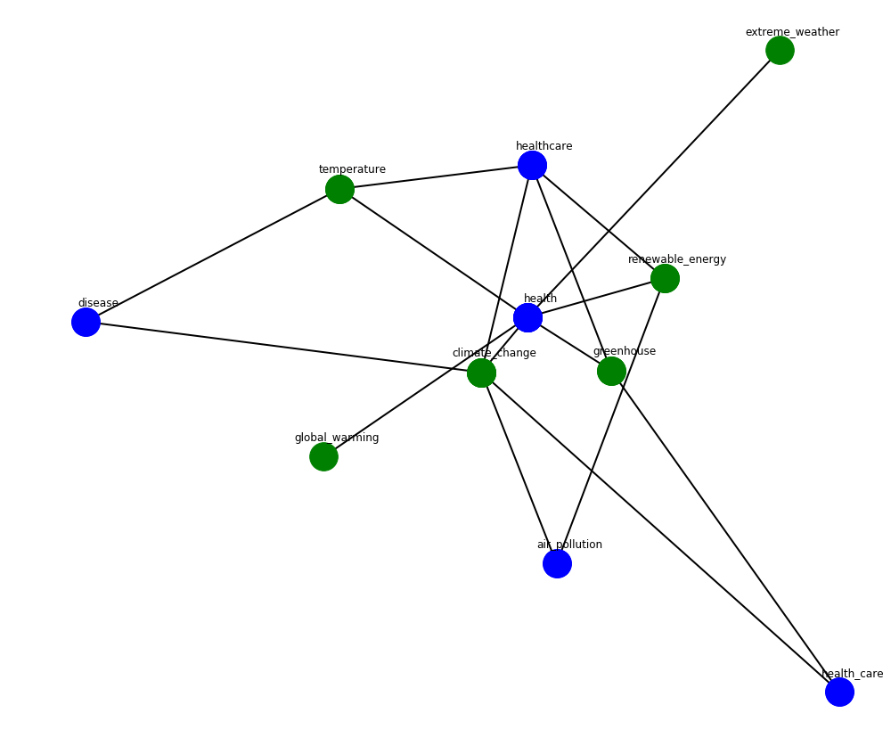

```python
import matplotlib.pyplot as plt
import networkx as nx
import numpy as np

G = nx.Graph()

health_nodes = []
climate_nodes = []

for word1 in hces_cooccurrence_matrix.keys():
    for word2 in hces_cooccurrence_matrix[word1].keys():
        if hces_cooccurrence_matrix[word1][word2] >= language_ref[focus_language]['min_coocurrence']:
            G.add_edge(word1, word2, weight=hces_cooccurrence_matrix[word1][word2])
            health_nodes.append(word1)
            climate_nodes.append(word2)

plt.figure(figsize=(17,15))

pos = nx.spring_layout(G)

pos_attrs = {}
for node, coords in pos.items():
    pos_attrs[node] = (coords[0] + 0.03, coords[1] + 0.05)

nx.draw_networkx_nodes(G, pos, nodelist=health_nodes, node_size=1000, node_color='b')
nx.draw_networkx_nodes(G, pos, nodelist=climate_nodes, node_size=1000, node_color='g')
nx.draw_networkx_edges(G, pos, edgelist=G.edges(data=True), width=2)
nx.draw_networkx_labels(G, pos_attrs, font_size=12, font_family='sans-serif')
#edge_labels = nx.get_edge_attributes(G,'weight')
#nx.draw_networkx_edge_labels(G, pos, edge_labels=edge_labels, font_size=10, font_family='sans-serif')

plt.axis('off')
plt.show()
```

### Exporting PDFs for selected sector

```python
dict_selected_pdfs_sector.keys()
```

```
dict_keys(['/system/attachments/10046/original/Tana_Netting_CSR_Report_2010.pdf?1303879734', '/system/attachments/10283/original/WDH_UNGC_COP_2011.pdf?1305122127', '/system/attachments/10420/original/COP_CDI_Dental_-_2011-05-15..pdf?1306151456', '/system/attachments/10481/original/Radiometer_Medical…
```

```python
pdfs_folder = "/Volumes/M/pdfs/"
hces_folder = '../data/cops/hces_pdfs/'
hces_folder2 = '../data/cops/hces_pdfs2/'
```

```python
import PyPDF2
import shutil
import nltk
import os
#import os.path

try:
    os.stat(pdfs_folder)
except:
    os.mkdir(pdfs_folder)

for pdf in dict_selected_pdfs_sector.keys():
    srcfile = pdfs_folder + filenameregex.search(pdf)[0]
    dstfile = hces_folder + filenameregex.search(pdf)[0]
    print("Copying %s to destination folder" % (srcfile))
    shutil.copyfile(srcfile, dstfile)
```

```python
FILENAME_SPLIT = re.compile('(.*)[/](.*)\?(.*)')
```

```python
test_string = '/system/attachments/10046/original/Tana_Netting_CSR_Report_2010.pdf?1303879734'
FILENAME_SPLIT.match(test_string).group(2)
```

```
'Tana_Netting_CSR_Report_2010.pdf'
```

```python
for pdf in dict_selected_pdfs_sector.keys():
    srcfile = hces_folder + filenameregex.search(pdf)[0]
    dstfile = hces_folder2 + FILENAME_SPLIT.match(pdf).group(2)
    print("Copying %s to destination folder" % (srcfile))
    shutil.copyfile(srcfile, dstfile)
```

[output not shown]

[output cut: 226 more lines]

[output not shown]